# Police Bulk Data

In pursuit of my interest in data that comes from our communities, I embarked on a search of public data from around my home state of Texas.

I came across a decently sized dataset published on the Dallas Open Data website by the Dallas Police Department in 2017. This dataset contains information on type of offense, when and where it happened, and a few descriptors on the offendor.

As a data scientist, my objective with this project is purely to investigate the data, highlight any patterns I can find, and see if I can make predictions. In line with thinking like a data scientist, we must ask questions. More specifically, we must develop hypotheses to test as we investigate the data.

### Questions: Low hanging fruit

1. What are the most common offenses across the board?
2. What is the distribution of offenses across zipcodes?
3. Are there certain offenses that only occur in specific zipcodes? Certain ages that offend in certain zipcodes?
4. Are there seasonal patterns in offense instances? - peaks and lows?
5. What is the percentage of offendors, by demographic (ex. Age, Race, Gender)?
6. Do demographic factors have a relationship to type of offense? (Multi-part question)

```python
import pandas as pd

from IPython.core.interactiveshell import InteractiveShell
InteractiveShell.ast_node_interactivity = 'all'

import matplotlib.pyplot as plt
% matplotlib inline
```

```python
df = pd.read_table('Police_Bulk_Data.csv', sep=',', encoding='UTF-8')
df.drop('AgencyName', axis=1, inplace=True)
df.offensezip = df.offensezip.fillna(0).astype(int)
```

```python
df.offensedescription.value_counts()[:50]
```

```
CRIMINAL MISCHIEF                 5966
BMV                               5154
THEFT                             4703
UUMV                              3414
FOUND PROPERTY                    2230
RUNAWAY                           1856
ASSAULT M/C                       1403
BURGLARY OF RESIDENCE             1281
BURGLARY                          1257
ACC INV DMG VEHICLE               1206
INJURED PERSON                    1181
RECKLESS DAMAGE                   1090
WANT TO LOCATE                    1044
ASSAULT M/A                        933
ACC INV DMG VEH                    822
AGG ROBBERY                        748
ASSAULT F/V M/A                    651
LOST PROPERTY                      649
INV OF THEFT                       645
SEIZED PROPERTY                    640
BURGLARY OF A RESIDENCE            546
DUTY ON STRIKE UNATTEND VEH        530
ROBBERY                            523
INVESTIGATION OF THEFT             510
BURGLARY OF HABITATION             446
CRIMINAL TRESPASS                  442
THEFT SHOPLIFT                     439
BURGLARY OF MOTOR VEHICLE          406
ASSAULT FV M/A                     404
UNEXPLAINED DEATH                  389
AGG ASSAULT                        387
AGGRAVATED ROBBERY                 376
SEXUAL ASSAULT                     354
BURGLARY OF BUSINESS               344
ASSAULT M/A F/V                    343
ASSAULT F/V M/C                    334
INV OF IDENTITY THEFT              331
DEADLY CONDUCT                     330
ASSAULT M/A (FV)                   323
PRISONER PROPERTY                  312
FORGERY                            308
AUTO ACCESSORY THEFT               294
ASSAULT                            280
BURGLARY OF A MOTOR VEHICLE        272
ASSAULT M/A FV                     268
THEFT OF SERVICE                   263
AGGRAVATED ASSAULT                 253
ASSAULT FV M/C                     250
BURG OF RESIDENCE                  249
DUTY ON STRIKE FIX OR HWY LAND     238
Name: offensedescription, dtype: int64
```

```python
df.offensezip.head()
```

[output not shown]

```python
# df.offensezip.value_counts()
df[['offensezip', 'offensedescription', 'AgencyORI']].groupby(['offensezip', 'offensedescription']).count() \
                          .sort_values('AgencyORI', ascending=False)
```

| offensezip | offensedescription | AgencyORI |
| --- | --- | --- |
| 0 | CRIMINAL MISCHIEF | 461 |
| 75217 | CRIMINAL MISCHIEF | 437 |
| 0 | BMV | 407 |
|  | THEFT | 385 |
| 75243 | CRIMINAL MISCHIEF | 350 |
| 0 | FOUND PROPERTY | 345 |
| 75216 | CRIMINAL MISCHIEF | 312 |
| 75217 | BMV | 275 |
| 75228 | CRIMINAL MISCHIEF | 269 |
| 75227 | CRIMINAL MISCHIEF | 268 |
| 75217 | FOUND PROPERTY | 268 |
| 75220 | CRIMINAL MISCHIEF | 264 |
| 75217 | UUMV | 252 |
| 0 | UUMV | 242 |
| 75211 | CRIMINAL MISCHIEF | 234 |
|  | BMV | 231 |
| 75243 | THEFT | 220 |
| 75217 | THEFT | 211 |
| 0 | RUNAWAY | 207 |
| 75211 | FOUND PROPERTY | 190 |
| 75220 | THEFT | 190 |
| 75228 | THEFT | 190 |
| 75216 | THEFT | 186 |
| 75227 | BMV | 180 |
| 75216 | BMV | 180 |
| 75220 | BMV | 171 |
| 75211 | THEFT | 170 |
| 75243 | BMV | 169 |
| 75220 | FOUND PROPERTY | 165 |
| 75287 | CRIMINAL MISCHIEF | 163 |
| ... | ... | ... |
| 75211 | THEFT OF PERSON | 1 |
|  | THEFT OF LADIES WALLET | 1 |
|  | THEFT OF FIREARM | 1 |
|  | THEFT OF BUSINESS | 1 |
|  | THEFT OF AUTO ACCESSORIE | 1 |
|  | THEFT-SECURITY CAMERAS | 1 |
|  | THEFT-THEFT FROM PERSON | 1 |
|  | UNEXPLAINED DEATH//NATURAL | 1 |
|  | THREATENING TEXT MESSAGES | 1 |
|  | UNEXPL DEATH//NATURAL DEATH | 1 |
|  | UNEXP DEATH NATURAL DEATH | 1 |
|  | UMMV | 1 |
|  | U.U.V. | 1 |
|  | TRAFFIC FATALITY #98 | 1 |
|  | TRAFFIC FATALITY # 75 | 1 |
|  | TOWED VEHICLE (ABANDONED) | 1 |
|  | TOWED VEHICLE | 1 |
|  | THREATENING TEXTS | 1 |
|  | THREATENING TEXT MESSAGE | 1 |
|  | THEFT/ SHOPLIFT | 1 |
|  | THREATENING PHONE CALLS/TEXTS | 1 |
|  | THREATENING PHONE CALL/TEXT | 1 |
|  | THEFTSHOPLIFT | 1 |
|  | THEFT/50-500 M/B (SHOPLIFT) | 1 |
|  | THEFT/50-500 M/B (SHOPLIFT) | 1 |
|  | THEFT/2 PRIOR CONVICTIONS | 1 |
|  | THEFT/1500-20K | 1 |
|  | THEFT//FORGERY | 1 |
|  | THEFT/ SHOPLIFT SJF | 1 |
| 99999 | RECKLESS DAMAGE | 1 |

28815 rows × 1 columns

```
<BarContainer object of 59 artists>
```

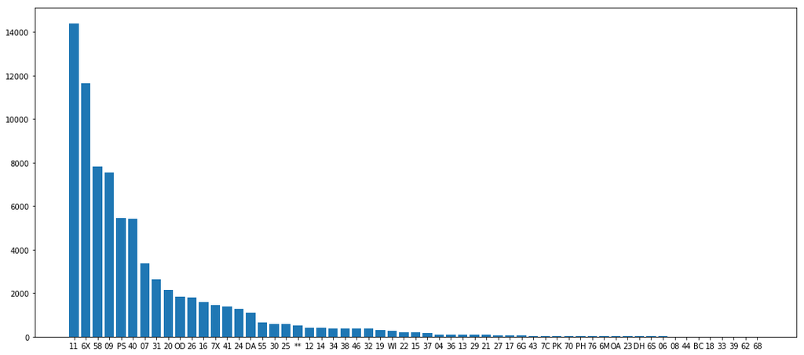

```python
plt.figure(figsize=(18, 8))
plt.bar(df.offensesignal1.value_counts().index, df.offensesignal1.value_counts().values)
plt.show()
```

```python
df.offensesignal1.value_counts().index
```

```
Index(['11', '6X', '58', '09', 'PS', '40', '07', '31', '20', 'OD', '26', '16',
       '7X', '41', '24', 'DA', '55', '30', '25', '**', '12', '14', '34', '38',
       '46', '32', '19', 'WI', '22', '15', '37', '04', '36', '13', '29', '21',
       '27', '17', '6G', '43', '7C', 'PK', '70', 'PH', '76', '6M', 'OA', '23',
       'DH', '6S', '06', '08', '44', 'BC', '18', '33', '39', '62', '68'],
      dtype='object')
```

```python
len(df.offensedescription.value_counts().values)
```

```
9089
```

```python
df.columns
```

```
Index(['AgencyORI', 'offenseservicenumber', 'offensedate',
       'offensereporteddate', 'offensedescription', 'offensestarttime',
       'offensestoptime', 'offensetimedispatched', 'offensebeat',
       'offensereportingarea', 'offensewatch', 'offensesignal1',
       'offensesignal2', 'offensename', 'offenserace', 'offensegender',
       'offenseage', 'offenseblock', 'offensedirection', 'offensestreet',
       'offenseapartment', 'offensecity', 'offensestate', 'offensezip',
       'offensebusinessblock', 'offensebusinessdirection',
       'offensebusinessstreet', 'offensebusinesscity',
       'offensepropertyattackcode', 'offensepremises',
       'offensedateofoccurence1', 'offensetimeofoccurence1',
       'offensedateofoccurence2', 'offensetimeofoccurence2', 'offenseucr1',
       'offenseucr2', 'offensemethodofoffense', 'offenseweather',
       'offensefamilyviolence', 'offensegangacitivty',
       'offensereportofficerbadge1', 'offensereportingofficerbadge2',
       'offenserecorddate', 'offensestatus'],
      dtype='object')
```

```python
df.offensestatus.value_counts()
```

```
Suspended                        57363
Cleared by Arrest                 9989
Cleared by Exceptional Arrest     5101
Administratively Closed           3620
Open                              3240
Unfounded                         1685
C                                   13
System.Xml.XmlElement                7
Name: offensestatus, dtype: int64
```